# dual-task-analysis_RR1_additions

Drew E. Winters, PhD.

02 April, 2025

# 1 Reasoning and Rationaile

## 1.1 Reviewers requested an additional analysis using inverse efficiency

- This metric represents “the average energy consumed by the system over trials” (Townsend & Ashby, 1983, p. 204).
- Thus can be interpreted as an quantification of cognitive load.
- Citation:
  - Townsend, J. T., & Ashby, F. G. (1983). Stochastic modelling of elementary psychological processes. New York, NY: Cambridge University Press.

## 1.2 Forumua for inverse efficiency (in r code terms)

- mean(Reaction Time) / (Percent Correct)
- Citations:
  - Akhtar, N., & Enns, J. T. (1989). Relations between covert orienting and filtering in the development of visual attention. Journal of Experimental Child Psychology, 48, 315–334. doi:https://doi.org/10.1016/0022-0965(89)90008-8
  - Bruyer, R., & Brysbaert, M. (2011). Combining speed and accuracy in cognitive psychology: Is the inverse efficiency score (IES) a better dependent variable than the mean reaction time (RT) and the percentage of errors (PE)? Psychologica Belgica, 51, 5–13. doi:https://doi.org/10.5334/pb-51-1-5

# 2 Setup

## 2.1 Packages Used

```r
  ## confirmatory factor analysis
library(lavaan)
  ## Power analysis
library(simr)

  ## model testing for mixed effects
library(lmerTest) # mixed effects modeling

  ## for model diagnostics
library(performance)
library(see)

  # for plotting
library(dplyr)
library(magrittr)
library(forcats)
library(ggplot2)
```

## 2.2 Data Loading

```r
dat <- read.csv(file.path(dataframe_final_subs))
```

## 2.3 Functions Used

### 2.3.1 Bootstrapping and Reporting

```r
  # function for reporting bootstrapped corrected values
mix_boot_report <- function(model, data=dat_long) {
  # functions
    ## 1) extract parameters for bootstrapping
  mySumm2 <- function(.) {
    c(
      beta=fixef(.),                                # fixed effects
      tval=as.data.frame(
        summary(.)$coefficients
        )$`t value`,                                # t values (p correction)
      sigma_resid_sd=sigma(.),                      # random residual sd
      signa_resid_var=var(resid(.)),                # random residual variance
      sig01_random_eff_sd=sqrt(unlist(VarCorr(.))), # random effect sd
      sig01_random_eff_var=unlist(VarCorr(.))       # random effect variance
    )
  }
    ## 2) Satterwaite correction for bootstrapped corrected p values
  sat_p_val <- function(dof_mod, boot_df, tind) {
    p_vals <- list()
    dof <- as.data.frame(summary(dof_mod)$coefficients)$df
    dof_ind <- 0
    for (ii in tind) {
      dof_ind <- (dof_ind + 1)
      p_value <- 2 * (
        1 - pt(abs(as.data.frame(boot_df$stats$rep.mean)[ii,]), dof[dof_ind])
        )
      p_vals <- append(p_vals,p_value)
    }
    return(unlist(p_vals))
  }

  # bootstrapping
  set.seed(1985) # setting seed
  boot.ci <- lmeresampler::bootstrap(
    lme4::lmer(
      model,
      data = data),
    .f= mySumm2,
    B = 10000,
    type = "reb",
    reb_type = 1)
    # we resample 10,000 bootstraps for proper estimation fo CIs
    # we use random effect block bootstrapping
      # a non-parametric bootstrap resampling (1) residuals (2) within clusters
        ## (1) Residual resampling does not impose normality of residuals
          #> addresses issues with the model if residuals are non-normal
          #> this makes residual bootstrapping a more reliable than parametric
          #> see this link: https://www.jstor.org/stable/43304840
          #> https://www.stat.cmu.edu/~cshalizi/uADA/13/lectures/which-bootstrap-when.pdf
        ## (2) looseness assumptions on the residual covariance structure
          #> i.e., this approach doesn't require a specific covariance structure
          #> this is important because:
            #> subjects in the non-test condition are expected to not change
            #> loosening this assumption improves estimation for this task
      # this method is robust to failure of dependence assumptions in MLM
        ## see: https://www.jstor.org/stable/43304840

  # identifying indices for metrics extracted
  beta_ind = which(
    startsWith(as.data.frame(confint(boot.ci, type = "norm"))$term, "beta"))
  tval_ind = which(
    startsWith(as.data.frame(confint(boot.ci, type = "norm"))$term, "tval"))
  resid_sd_ind = which(
    startsWith(as.data.frame(
      confint(boot.ci, type = "norm"))$term, "sigma_resid_sd"))
  rand_eff_sd_ind = which(
    startsWith(as.data.frame(
      confint(boot.ci, type = "norm"))$term, "signa_resid_var"))
  resid_var_ind = which(
    startsWith(as.data.frame(
      confint(boot.ci, type = "norm"))$term, "sig01_random_eff_sd"))
  rand_eff_var_ind = which(
    startsWith(as.data.frame(
      confint(boot.ci, type = "norm"))$term, "sig01_random_eff_var"))

  # extracting corrected betas
  total_results <- as.data.frame(
    boot.ci[5])[beta_ind , c("stats.term", "stats.rep.mean", "stats.se")]
  colnames(total_results) <- c("term", "beta.boot", "se.boot")

  # extracting corrected t values
  t_df <- as.data.frame(
    as.data.frame(boot.ci[5])[tval_ind , c("stats.rep.mean")])
  colnames(t_df) <- "t.boot"
  total_results <- cbind(total_results, t_df)

  # extracting corrected p values
  p_df <- as.data.frame(sat_p_val(model,boot.ci,tval_ind))
  colnames(p_df) <- "p.satw_boot"
  total_results <- cbind(total_results, p_df)

  # extracting corrected random effects
    ## var
  rand_var <- as.data.frame(
    as.data.frame(boot.ci[5])[rand_eff_var_ind , c("stats.rep.mean")])
  rand_var <- cbind("rand_var",rand_var)
  rand_var_se <- as.data.frame(boot.ci[5])[rand_eff_var_ind , c("stats.se")]
  rand_var <- cbind(rand_var,t(as.data.frame(c(rand_var_se,NA,NA))))
  colnames(rand_var) <- colnames(total_results)
  rownames(rand_var) <- 21
  total_results <- rbind(total_results, rand_var)
    ## sd
  rand_sd <- as.data.frame(
    as.data.frame(boot.ci[5])[rand_eff_sd_ind , c("stats.rep.mean")])
  rand_sd <- cbind("rand_sd",rand_sd)
  rand_sd_se <- as.data.frame(boot.ci[5])[rand_eff_sd_ind , c("stats.se")]
  rand_sd <- cbind(rand_sd,t(as.data.frame(c(rand_sd_se,NA,NA))))
  colnames(rand_sd) <- colnames(total_results)
  rownames(rand_sd) <- 22
  total_results <- rbind(total_results, rand_sd)

  # extracting corrected random effect residuals
    ## var
  resid_var <- as.data.frame(
    as.data.frame(boot.ci[5])[resid_var_ind , c("stats.rep.mean")])
  resid_var <- cbind("resid_var",resid_var)
  resid_var_se <- as.data.frame(boot.ci[5])[resid_var_ind , c("stats.se")]
  resid_var <- cbind(resid_var,t(as.data.frame(c(resid_var_se,NA,NA))))
  colnames(resid_var) <- colnames(total_results)
  rownames(resid_var) <- 23
  total_results <- rbind(total_results, resid_var)
    ## sd
  resid_sd <- as.data.frame(
    as.data.frame(boot.ci[5])[resid_sd_ind , c("stats.rep.mean")])
  resid_sd <- cbind("resid_sd",resid_sd)
  resid_sd_se <- as.data.frame(boot.ci[5])[resid_sd_ind , c("stats.se")]
  resid_sd <- cbind(resid_sd,t(as.data.frame(c(resid_sd_se,NA,NA))))
  colnames(resid_sd) <- colnames(total_results)
  rownames(resid_sd) <- 24
  total_results <- rbind(total_results, resid_sd)

  # extracting bootstrapped confidence intervals (CI)
    ## for betas we use the percentile confidence interval
      ### this method uses percentiles of the bootstrap sampling distribution
          # and does not impose assumptions of distribution normality
      ### we use this because the non-normality of interactions and standard
          # error equation is not straight forward for interaction terms
          # see: https://www.e-education.psu.edu/eme210/node/608
    ## for random effects we use normal confidence intervals
      ### this method uses the standard error of the sampling distribution and
          # imposes assumptions of normality.
      ### but why do this?
        #### mixed effects already imposes assumptions of normality on residual
            # distribution in its estimation
        #### The random effect residual distribution is theoretical as a source
            # of unknown variance thus is should be normal
        #### bootstrapping should make residual distribution normal over 10,000
            # resamples (if not already normal)
        #### it is important to note that this will have no bearing on the
            # inferences made for the betas predicting the outcome of interest
        #### practically this won't make a substantive difference but
            # theoretically this seems most sound
    ## why use one CI method for on and another method for another?
      ### to summarize the case for why we would use different CI methods:
        #### non-normality of betas need to be considered
        #### normal distribution of random effect residuals needs considered
  beta.ci <- as.data.frame(
    confint(boot.ci, type = "perc"))[beta_ind , c("lower", "upper")]
  rand_eff_sd.ci <- as.data.frame(
    confint(boot.ci, type = "norm"))[rand_eff_sd_ind , c("lower", "upper")]
  resid_sd.ci <- as.data.frame(
    confint(boot.ci, type = "norm"))[resid_sd_ind , c("lower", "upper")]
  rand_eff_var.ci <- as.data.frame(
    confint(boot.ci, type = "norm"))[rand_eff_var_ind , c("lower", "upper")]
  resid_var.ci <- as.data.frame(
    confint(boot.ci, type = "norm"))[resid_var_ind , c("lower", "upper")]
  beta.boot_ci <- rbind(
    beta.ci,rbind(rand_eff_sd.ci,resid_sd.ci))
  beta.boot_ci <- rbind(
    beta.boot_ci,rbind(rand_eff_var.ci,resid_var.ci))
  colnames(beta.boot_ci) <- c("ci.boot_low", "ci.boot_hi")
  total_results <- cbind(total_results, beta.boot_ci)

  # extracting r2 values
  r2_vals <- performance(model)
  r2s <- rbind(c(as.data.frame(r2_vals)$R2_marginal,NA,NA,NA,NA,NA),
               c(as.data.frame(r2_vals)$R2_conditional,NA,NA,NA,NA,NA))
  r2s <- cbind(as.data.frame(c("R2.marginal","R2.conditional")),r2s)
  colnames(r2s) <- colnames(total_results)
  rownames(r2s) <- c(25, 26)
  total_results <- rbind(total_results, r2s)

  # removing "beta." prefix to term names
  total_results$term <- stringr::str_replace_all(
    total_results$term, "beta.", "")

  # removing term column and making row name
  rownames(total_results) <- total_results$term
  total_results <- total_results[,2:7]

  # returning dataframe at 3 digits
  return(format(total_results ,digits = 3))
}
```

## 2.4 Structuring Data

### 2.4.1 Calculating Inverse Efficiency Scores

- We use this metric as a supplemental analysis to indicate the amount of energy consumed
  - higher values = more energy consumed
  - lower values = less energy consumed
- Given that some inf values will be produced for the control subjects (indicating an infinitesimally small value)
  - we replace inf with 0 (as they are not missing just very very small indicating 0 for our purposes)

```r
## single
dat$tom_s_at_inv_eff <- (dat$tom_s_rt_at_mean/((dat$tom_s_acc_at_sum/10)))
dat$tom_s_at_inv_eff [which(dat$tom_s_at_inv_eff  == Inf)] <- 0

dat$tom_s_ct_inv_eff <- (dat$tom_s_rt_ct_mean/((dat$tom_s_acc_ct_sum/10)))
dat$tom_s_ct_inv_eff [which(dat$tom_s_ct_inv_eff  == Inf)] <- 0

dat$tom_s_pc_inv_eff <- (dat$tom_s_rt_pc_mean/((dat$tom_s_acc_pc_sum/10)))
dat$tom_s_pc_inv_eff [which(dat$tom_s_pc_inv_eff  == Inf)] <- 0

dat$tom_s_total_inv_eff <- (dat$tom_s_rt_total_mean/((dat$tom_s_acc_total_sum/30)))
dat$tom_s_total_inv_eff [which(dat$tom_s_total_inv_eff  == Inf)] <- 0


## dual
dat$tom_d_at_inv_eff <- (dat$tom_d_rt_at_mean/((dat$tom_d_acc_at_sum/10)))
dat$tom_d_at_inv_eff [which(dat$tom_d_at_inv_eff  == Inf)] <- 0

dat$tom_d_ct_inv_eff <- (dat$tom_d_rt_ct_mean/((dat$tom_d_acc_ct_sum/10)))
dat$tom_d_ct_inv_eff [which(dat$tom_d_ct_inv_eff  == Inf)] <- 0

dat$tom_d_pc_inv_eff <- (dat$tom_d_rt_pc_mean/((dat$tom_d_acc_pc_sum/10)))
dat$tom_d_pc_inv_eff [which(dat$tom_d_pc_inv_eff  == Inf)] <- 0

dat$tom_d_total_inv_eff <- (dat$tom_d_rt_total_mean/((dat$tom_d_acc_total_sum/30)))
dat$tom_d_total_inv_eff [which(dat$tom_d_total_inv_eff  == Inf)] <- 0
```

- Repeated measures (Long) Data

```r
  # stacking variables
ids <- rep(1:length(dat$tom_s_acc_total_sum),2)
time<- c(rep(0, length(dat$tom_s_acc_total_sum)),
         rep(1, length(dat$tom_s_acc_total_sum)))
cu_long<- c(dat$cu_total_mean,dat$cu_total_mean)
sdq_cd_long<- c((dat$sdq_cd/5),(dat$sdq_cd/5)) # for a mean score
tom_acc_total<- c(dat$tom_s_acc_total_sum,dat$tom_d_acc_total_sum)
tom_acc_at<- c(dat$tom_s_acc_at_sum,dat$tom_d_acc_at_sum)
tom_acc_ct<- c(dat$tom_s_acc_ct_sum,dat$tom_d_acc_ct_sum)
tom_acc_pc<- c(dat$tom_s_acc_pc_sum,dat$tom_d_acc_pc_sum)
tom_rt_total<- c(dat$tom_s_rt_total_mean,dat$tom_d_rt_total_mean)
tom_rt_at<- c(dat$tom_s_rt_at_mean,dat$tom_d_rt_at_mean)
tom_rt_ct<- c(dat$tom_s_rt_ct_mean,dat$tom_d_rt_ct_mean)
tom_rt_pc<- c(dat$tom_s_rt_pc_mean,dat$tom_d_rt_pc_mean)
sex_male_long<- c(dat$sex_male , dat$sex_male )
race_white_long<- c(dat$race_white , dat$race_white )
iq_long<- c(dat$iq , dat$iq )
careless_long<- c(dat$careless , dat$careless )
sdq_hyperactivity_long<- c((dat$sdq_hyperactivity/5),
                           (dat$sdq_hyperactivity/5)) # for a mean score
sdq_internalizing_long<- c((dat$sdq_internalizing/10),
                           (dat$sdq_internalizing/10)) # for a mean score
order_var_long<- c(dat$order_var , dat$order_var )
group_di_long<- c(dat$group_di , dat$group_di )

tom_inv_eff_at <- c(dat$tom_s_at_inv_eff,dat$tom_d_at_inv_eff)
tom_inv_eff_ct <- c(dat$tom_s_ct_inv_eff,dat$tom_d_ct_inv_eff)
tom_inv_eff_pc <- c(dat$tom_s_pc_inv_eff,dat$tom_d_pc_inv_eff)
tom_inv_eff_total <- c(dat$tom_s_total_inv_eff,dat$tom_d_total_inv_eff)

  # placing in long format dataframe
dat_long = data.frame(
  id = ids,
  time = time,
  cu = cu_long,
  sdq_cd = sdq_cd_long,
  tom_acc_total = tom_acc_total,
  tom_acc_at = tom_acc_at,
  tom_acc_ct = tom_acc_ct,
  tom_acc_pc = tom_acc_pc,
  tom_rt_total = tom_rt_total,
  tom_rt_at = tom_rt_at,
  tom_rt_ct = tom_rt_ct,
  tom_rt_pc = tom_rt_pc,
  sex_male = sex_male_long,
  race_white = race_white_long,
  iq = iq_long,
  careless = careless_long,
  sdq_hyperactivity = sdq_hyperactivity_long,
  sdq_internalizing = sdq_internalizing_long,
  order_var = order_var_long,
  group_di = group_di_long,
  tom_inv_eff_total=tom_inv_eff_total,
  tom_inv_eff_at=tom_inv_eff_at,
  tom_inv_eff_ct=tom_inv_eff_ct,
  tom_inv_eff_pc=tom_inv_eff_pc
)
```

### 2.4.2 Interaction terms

- Derived using Centered Residual Interaction Terms
- see:
  - https://doi.org/10.1177/0013164412445473
  - https://doi.org/10.1207/s15328007sem1304_1
- Also this approach keeps us from violating regression/mixed models assumptions
  - for assumptions see: https://doi.org/10.1177/1094428119877457

#### 2.4.2.1 Repeated Measure Interactions

- Repeated Measures (Long Form) Interactions

```r
  # group x time
dat_long$int_gptime <- resid(
  lm(I(group_di*time) ~ group_di+time, data=dat_long)
  )

  # cu x cd
dat_long$int_cdcu <- resid(
  lm(I(sdq_cd*cu) ~ sdq_cd+cu, data=dat_long)
  )
dat_long$int_cdcugp <- resid(
  lm(I(sdq_cd*cu*group_di) ~ sdq_cd+cu+group_di, data=dat_long)
  )
dat_long$int_cdcugptime <- resid(
  lm(I(sdq_cd*cu*group_di*time) ~ sdq_cd+cu+group_di+time, data=dat_long)
  )
dat_long$int_cdcutime <- resid(
  lm(I(sdq_cd*cu*time) ~ sdq_cd+cu+time, data=dat_long)
  )

  # cu
dat_long$int_cugp <- resid(
  lm(I(cu*group_di) ~ cu+group_di, data=dat_long)
  )
dat_long$int_cutime <- resid(
  lm(I(cu*time) ~ cu+time, data=dat_long)
  )
dat_long$int_cugptime <- resid(
  lm(I(cu*group_di*time) ~ cu+group_di+time, data=dat_long)
  )

  # cd
dat_long$int_cdgp <- resid(
  lm(I(sdq_cd*group_di) ~ sdq_cd+group_di, data=dat_long)
  )
dat_long$int_cdtime <- resid(
  lm(I(sdq_cd*time) ~ sdq_cd+time, data=dat_long)
  )
dat_long$int_cdgptime <- resid(
  lm(I(sdq_cd*group_di*time) ~ sdq_cd+group_di+time, data=dat_long)
  )
```

# 3 Supplemental Analyses

## 3.1 **Change in ToM - efficiency**

### 3.1.1 **Overall** ToM *efficiency*

#### 3.1.1.1 Model

```r
total_inv_eff_p <- lmer(tom_inv_eff_total  ~
                      cu +
                      sdq_cd +
                      sex_male +
                      race_white +
                      iq +
                      careless +
                      sdq_hyperactivity +
                      sdq_internalizing +
                      time +
                      group_di +
                      order_var +
                      int_gptime +
                      int_cdcu +
                      int_cdcugp +
                      int_cdcugptime +
                      int_cugp +
                      int_cugptime +
                      int_cdgp +
                      int_cdgptime +
                      (1|id),
                    data = dat_long
                    )
```

#### 3.1.1.2 Model performance

```r
(total_inv_eff_p_st <- performance(total_inv_eff_p))
```

| AIC | AICc | BIC | R2_conditional | R2_marginal | ICC | RMSE | Sigma |
| --- | --- | --- | --- | --- | --- | --- | --- |
| 807.9355 | 814.8198 | 876.923 | 0.4908556 | 0.1939765 | 0.3683255 | 1.773559 | 2.181983 |

#### 3.1.1.3 Results (boostrap corrected)

```r
# summary(total_inv_eff_p)
(tom_total_df <- mix_boot_report(total_inv_eff_p))
```

|  | beta.boot | se.boot | t.boot | p.satw_boot | ci.boot_low | ci.boot_hi |
| --- | --- | --- | --- | --- | --- | --- |
| (Intercept) | 7.0105 | 1.704 | 4.2780 | 5.76e-05 | 3.6361 | 10.35043 |
| cu | 0.6375 | 1.058 | 0.6353 | 5.27e-01 | -1.4777 | 2.74763 |
| sdq_cd | 3.6507 | 1.052 | 3.6161 | 5.60e-04 | 1.5722 | 5.71564 |
| sex_male | 0.2162 | 0.584 | 0.3908 | 6.97e-01 | -0.9462 | 1.35958 |
| race_white | -0.0212 | 0.601 | -0.0379 | 9.70e-01 | -1.2384 | 1.15181 |
| iq | -0.0251 | 0.016 | -1.6370 | 1.06e-01 | -0.0557 | 0.00801 |
| careless | -0.3882 | 0.682 | -0.5940 | 5.54e-01 | -1.7041 | 1.02525 |
| sdq_hyperactivity | -1.6438 | 0.682 | -2.5271 | 1.38e-02 | -2.9852 | -0.30633 |
| sdq_internalizing | -1.0261 | 0.971 | -1.1221 | 2.66e-01 | -2.9390 | 0.91671 |
| time | -0.0765 | 0.335 | -0.2442 | 8.08e-01 | -0.7256 | 0.59331 |

[output cut: 16 more lines]

```r
# saving results to csv
write.csv(
  tom_total_df,
  tom_change_efficiency_total,
  row.names=TRUE
  )
```

#### 3.1.1.4 Figures

##### 3.1.1.4.1 Organizing plot data

```r
dat_plot <- dat_long
dat_plot$random.intercpet.preds_efficiency_total <- predict(total_inv_eff_p)
dat_plot$hi_lo2<-ifelse(dat_plot$group_di == 0,"Control","Test")
dat_plot$time_rc<-ifelse(dat_plot$time == 0,"Single","Dual")
dat_plot$time_rc<-factor(dat_plot$time_rc, levels=c("Single","Dual"))
```

##### 3.1.1.4.2 Individual data plot

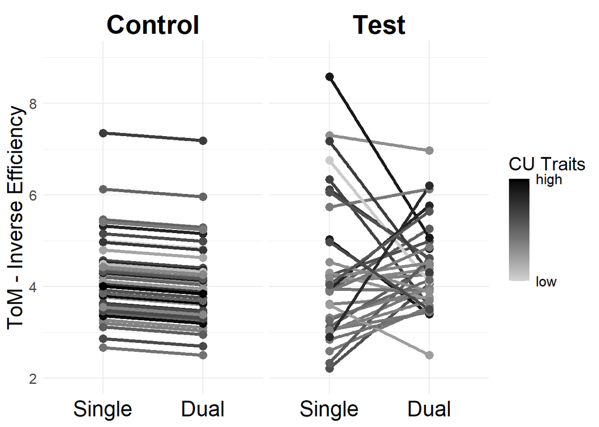

```r
  # CU_______
dat_plot %>%                 # data
  mutate(                    # to properly order control and test groups
    hi_lo = fct_relevel(
      hi_lo2,
      "Control",
      "Test")
    ) %>%
  ggplot(                   # plot
    aes(
      x=factor(time),
      y=random.intercpet.preds_efficiency_total,
      group = id,
      colour = cu)
    ) +
  geom_smooth(              # fit line
    method='lm',
    formula ='y ~ x',
    size=1.25
    ) +
  geom_point(size=3) +      # plot points
  labs(
    x=NULL,
    y="ToM - Inverse Efficiency"
    ) +
  scale_color_continuous(   # scale the color and labels accordingly
    "CU Traits",
    breaks = c(
      min(dat_plot$cu),
      max(dat_plot$cu)
      ),
    labels = c("low", "high"),
    type = "gradient",
    low="light grey",
    high="black"
    ) +
  ylim(2,9) +
  facet_wrap(~hi_lo)  +   # faceting plots by task (single ToM adn dual ToM)
  scale_x_discrete(
    labels=c(
      "Single",
      "Dual"
      )
    ) +
  theme_minimal() +       # setting theme and text parameters
  theme(
    axis.text=element_text(
      size=rel(1.1)
      ),
    axis.title=element_text(
      size=rel(1.6)
      ),
    strip.text.x.top = element_text(
      colour = "black",
      face = "bold",
      size=rel(2.5)
      ),
    axis.text.x = element_text(
      colour = "black",
      face="plain",
      size=rel(1.5)
      ),
    legend.title = element_text(
      size=rel(1.4)
      ),
    legend.text = element_text(
      size=rel(1.1)
      )
    )
```

```r
  # saving plot
ggsave(
  paste0(base_fig,"\\tom_total_efficiency_individual_line_CU.tiff"),
  plot = last_plot(),
  device = "tiff",
  scale = 1,
  width = 6,
  height = 7,
  units = "in",
  dpi = 300
)
```

##### 3.1.1.4.3 Average line by group

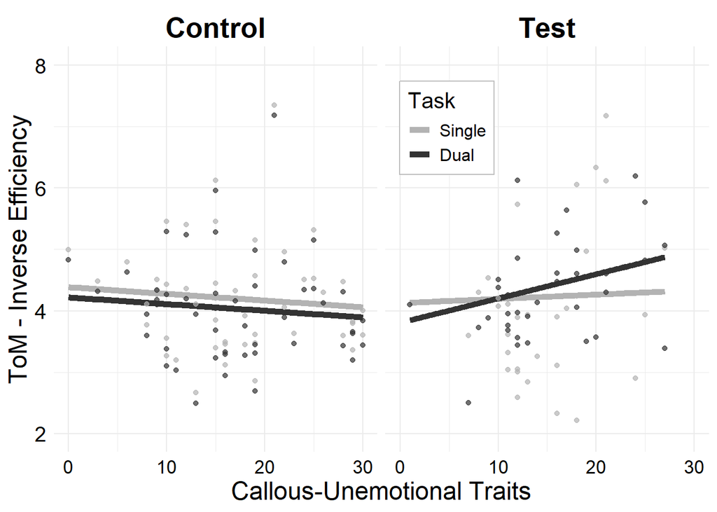

```r
  # CU______________
ggplot(
  data=dat_plot,
  aes(
    x=cu*22,                              # add denominator- rescale mean score
    y=random.intercpet.preds_efficiency_total,
    group = factor(time_rc),
    colour = factor(time_rc)
    )
  ) +
  geom_smooth(
    method='lm',
    se=FALSE,
    size=2
    ) +
  geom_point(alpha=0.7)+
  labs(
    x="Callous-Unemotional Traits",
    y="ToM - Inverse Efficiency"
    ) +
  scale_colour_grey(
    "Task",
    start = .7,
    end= .2
    ) +
  ylim(2,8) +
  facet_grid(. ~ fct_relevel(
    dat_plot$hi_lo2,
    "Control",
    "Test")
    ) +
  theme_minimal() +
  theme(
    axis.text=element_text(
      size=rel(1.1)
    ),
    axis.title=element_text(
      size=rel(1.6)
    ),
    strip.text.x.top = element_text(
      colour = "black",
      face = "bold",
      size=rel(2.25)
    ),
    axis.text.x = element_text(
      colour = "black",
      face="plain",
      size=rel(1.1)
    ),
    axis.text.y = element_text(
      colour = "black",
      face="plain",
      size=rel(1.2)
    ),
    legend.title = element_text(
      size=rel(1.4)
    ),
    legend.text = element_text(
      size=rel(1.1)
    ),
    legend.position = c(0.6,0.8),
    legend.background = element_rect(
      fill="white",
      color = "grey")
    )
```

```r
ggsave(
  paste0(base_fig,"\\tom_total_efficiency_task_line_CU.tiff"),
  plot = last_plot(),
  device = "tiff",
  scale = 1,
  width = 5.5,
  height = 4.5,
  units = "in",
  dpi = 300
)
```

### 3.1.2 **Affective** ToM *efficiency*

#### 3.1.2.1 Model

```r
at_inv_eff_p <- lmer(tom_inv_eff_at  ~
                      cu +
                      sdq_cd +
                      sex_male +
                      race_white +
                      iq +
                      careless +
                      sdq_hyperactivity +
                      sdq_internalizing +
                      time +
                      group_di +
                      order_var +
                      int_gptime +
                      int_cdcu +
                      int_cdcugp +
                      int_cdcugptime +
                      int_cugp +
                      int_cugptime +
                      int_cdgp +
                      int_cdgptime +
                      (1|id),
                    data = dat_long
                    )
```

#### 3.1.2.2 Model performance

```r
(at_inv_eff_p_st <- performance(at_inv_eff_p))
```

| AIC | AICc | BIC | R2_conditional | R2_marginal | ICC | RMSE | Sigma |
| --- | --- | --- | --- | --- | --- | --- | --- |
| 866.1683 | 873.0526 | 935.1558 | 0.3109322 | 0.1604285 | 0.1792624 | 2.537165 | 2.915769 |

#### 3.1.2.3 Results (boostrap corrected)

```r
# summary(at_inv_eff_p)
(tom_at_df <- mix_boot_report(at_inv_eff_p))
```

|  | beta.boot | se.boot | t.boot | p.satw_boot | ci.boot_low | ci.boot_hi |
| --- | --- | --- | --- | --- | --- | --- |
| (Intercept) | 4.4999 | 1.8535 | 2.4686 | 0.01594 | 0.8256 | 8.1644 |
| cu | 2.0348 | 1.1591 | 1.8220 | 0.07273 | -0.2670 | 4.2873 |
| sdq_cd | 0.0474 | 1.1571 | 0.0430 | 0.96583 | -2.2336 | 2.3490 |
| sex_male | -0.8210 | 0.6347 | -1.3331 | 0.18683 | -2.0652 | 0.4319 |
| race_white | 0.1283 | 0.6574 | 0.2007 | 0.84154 | -1.1650 | 1.4002 |
| iq | -0.0138 | 0.0173 | -0.8085 | 0.42154 | -0.0476 | 0.0214 |
| careless | 0.6872 | 0.7553 | 0.9462 | 0.34730 | -0.7758 | 2.1734 |
| sdq_hyperactivity | -0.0427 | 0.7485 | -0.0586 | 0.95342 | -1.5277 | 1.4278 |
| sdq_internalizing | -0.8113 | 1.0394 | -0.7981 | 0.42750 | -2.8139 | 1.2403 |
| time | 0.7441 | 0.4486 | 1.7359 | 0.08642 | -0.1232 | 1.6278 |

[output cut: 16 more lines]

```r
# saving results to csv
write.csv(
  tom_at_df,
  tom_change_efficiency_affective,
  row.names=TRUE
  )
```

#### 3.1.2.4 Figures

##### 3.1.2.4.1 Organizing plot data

```r
dat_plot$random.intercpet.preds_efficiency_at <- predict(at_inv_eff_p)
```

##### 3.1.2.4.2 Individual data plot

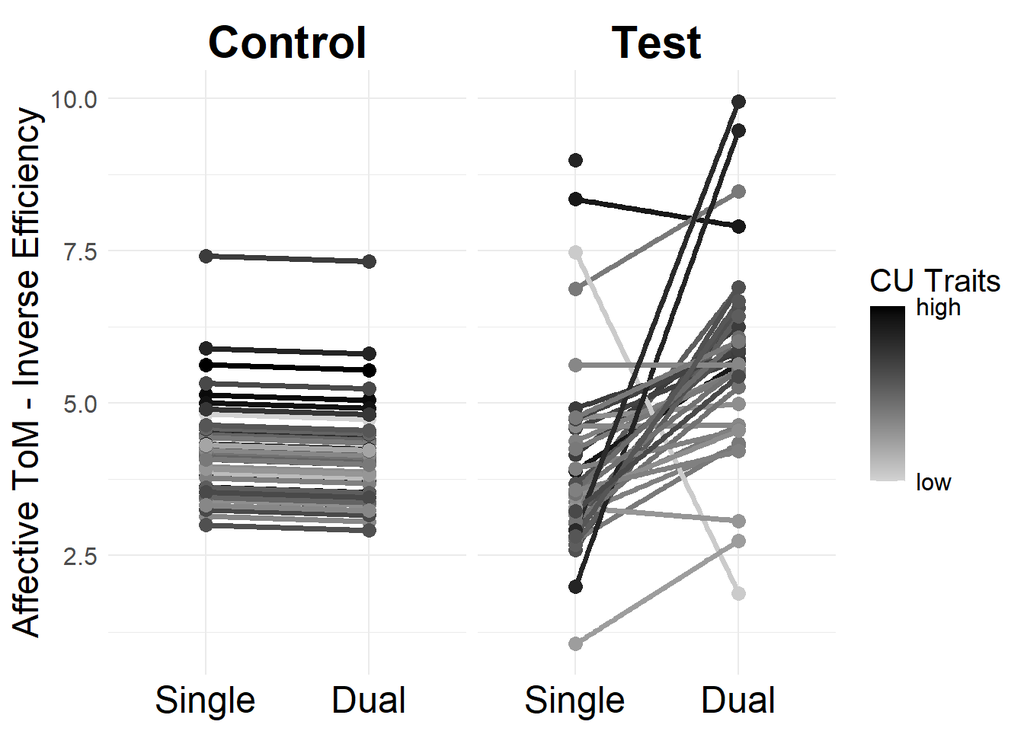

```r
  # CU_______
dat_plot %>%                 # data
  mutate(                    # to properly order control and test groups
    hi_lo = fct_relevel(
      hi_lo2,
      "Control",
      "Test")
    ) %>%
  ggplot(                   # plot
    aes(
      x=factor(time),
      y=random.intercpet.preds_efficiency_at,
      group = id,
      colour = cu)
    ) +
  geom_smooth(              # fit line
    method='lm',
    formula ='y ~ x',
    size=1.25
    ) +
  geom_point(size=3) +      # plot points
  labs(
    x=NULL,
    y="Affective ToM - Inverse Efficiency"
    ) +
  scale_color_continuous(   # scale the color and labels accordingly
    "CU Traits",
    breaks = c(
      min(dat_plot$cu),
      max(dat_plot$cu)
      ),
    labels = c("low", "high"),
    type = "gradient",
    low="light grey",
    high="black"
    ) +
  ylim(1,10) +
  facet_wrap(~hi_lo)  +   # faceting plots by task (single ToM adn dual ToM)
  scale_x_discrete(
    labels=c(
      "Single",
      "Dual"
      )
    ) +
  theme_minimal() +       # setting theme and text parameters
  theme(
    axis.text=element_text(
      size=rel(1.1)
      ),
    axis.title=element_text(
      size=rel(1.6)
      ),
    strip.text.x.top = element_text(
      colour = "black",
      face = "bold",
      size=rel(2.5)
      ),
    axis.text.x = element_text(
      colour = "black",
      face="plain",
      size=rel(1.5)
      ),
    legend.title = element_text(
      size=rel(1.4)
      ),
    legend.text = element_text(
      size=rel(1.1)
      )
    )
```

```r
  # saving plot
ggsave(
  paste0(base_fig,"\\tom_at_efficiency_individual_line_CU.tiff"),
  plot = last_plot(),
  device = "tiff",
  scale = 1,
  width = 6,
  height = 7,
  units = "in",
  dpi = 300
)
```

##### 3.1.2.4.3 Average line by group

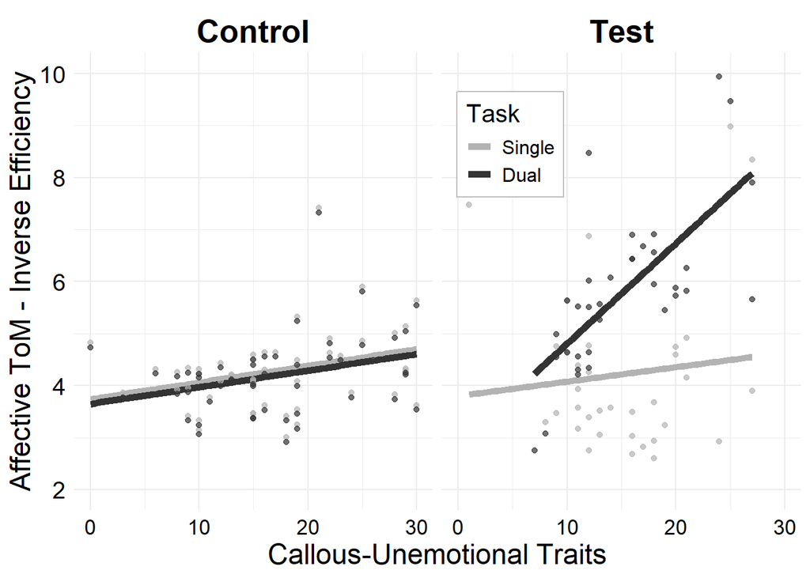

```r
  # CU______________
ggplot(
  data=dat_plot,
  aes(
    x=cu*22,                              # add denominator- rescale mean score
    y=random.intercpet.preds_efficiency_at,
    group = factor(time_rc),
    colour = factor(time_rc)
    )
  ) +
  geom_smooth(
    method='lm',
    se=FALSE,
    size=2
    ) +
  geom_point(alpha=0.7)+
  labs(
    x="Callous-Unemotional Traits",
    y="Affective ToM - Inverse Efficiency"
    ) +
  scale_colour_grey(
    "Task",
    start = .7,
    end= .2
    ) +
  ylim(2,10) +
  facet_grid(. ~ fct_relevel(
    dat_plot$hi_lo2,
    "Control",
    "Test")
    ) +
  theme_minimal() +
  theme(
    axis.text=element_text(
      size=rel(1.1)
    ),
    axis.title=element_text(
      size=rel(1.6)
    ),
    strip.text.x.top = element_text(
      colour = "black",
      face = "bold",
      size=rel(2.25)
    ),
    axis.text.x = element_text(
      colour = "black",
      face="plain",
      size=rel(1.1)
    ),
    axis.text.y = element_text(
      colour = "black",
      face="plain",
      size=rel(1.2)
    ),
    legend.title = element_text(
      size=rel(1.4)
    ),
    legend.text = element_text(
      size=rel(1.1)
    ),
    legend.position = c(0.6,0.8),
    legend.background = element_rect(
      fill="white",
      color = "grey")
    )
```

```r
ggsave(
  paste0(base_fig,"\\tom_at_efficiency_task_line_CU.tiff"),
  plot = last_plot(),
  device = "tiff",
  scale = 1,
  width = 5.5,
  height = 4.5,
  units = "in",
  dpi = 300
)
```

### 3.1.3 **Cognitive** ToM *efficiency*

#### 3.1.3.1 Model

```r
ct_inv_eff_p <- lmer(tom_inv_eff_ct  ~
                      cu +
                      sdq_cd +
                      sex_male +
                      race_white +
                      iq +
                      careless +
                      sdq_hyperactivity +
                      sdq_internalizing +
                      time +
                      group_di +
                      order_var +
                      int_gptime +
                      int_cdcu +
                      int_cdcugp +
                      int_cdcugptime +
                      int_cugp +
                      int_cugptime +
                      int_cdgp +
                      int_cdgptime +
                      (1|id),
                    data = dat_long
                    )
```

#### 3.1.3.2 Model performance

```r
(ct_inv_eff_p_st <- performance(ct_inv_eff_p))
```

| AIC | AICc | BIC | R2_conditional | R2_marginal | ICC | RMSE | Sigma |
| --- | --- | --- | --- | --- | --- | --- | --- |
| 858.6709 | 865.5553 | 927.6585 | 0.7107744 | 0.1800966 | 0.6472443 | 1.614644 | 2.160038 |

#### 3.1.3.3 Results (boostrap corrected)

```r
# summary(ct_inv_eff_p)
(tom_ct_df <- mix_boot_report(ct_inv_eff_p))
```

|  | beta.boot | se.boot | t.boot | p.satw_boot | ci.boot_low | ci.boot_hi |
| --- | --- | --- | --- | --- | --- | --- |
| (Intercept) | 9.7172 | 2.4629 | 4.116 | 0.000103 | 4.8968 | 14.57730 |
| cu | -0.2975 | 1.5267 | -0.205 | 0.838066 | -3.3002 | 2.70603 |
| sdq_cd | 5.0323 | 1.5330 | 3.456 | 0.000937 | 2.0312 | 8.14286 |
| sex_male | 0.4893 | 0.8482 | 0.613 | 0.541734 | -1.2200 | 2.12784 |
| race_white | 0.1491 | 0.8859 | 0.179 | 0.858300 | -1.6670 | 1.87027 |
| iq | -0.0413 | 0.0232 | -1.870 | 0.065660 | -0.0837 | 0.00725 |
| careless | -0.9131 | 0.9949 | -0.967 | 0.336964 | -2.7103 | 1.21477 |
| sdq_hyperactivity | -2.0612 | 0.9958 | -2.197 | 0.031334 | -4.0236 | -0.06325 |
| sdq_internalizing | -1.3125 | 1.4103 | -0.995 | 0.323331 | -4.0819 | 1.53051 |
| time | -0.1744 | 0.3359 | -0.543 | 0.588415 | -0.8264 | 0.48833 |

[output cut: 16 more lines]

```r
# saving results to csv
write.csv(
  tom_ct_df,
  tom_change_efficiency_cognitive,
  row.names=TRUE
  )
```

#### 3.1.3.4 Figures

##### 3.1.3.4.1 Organizing plot data

```r
dat_plot$random.intercpet.preds_efficiency_ct <- predict(ct_inv_eff_p)
```

##### 3.1.3.4.2 Individual data plot

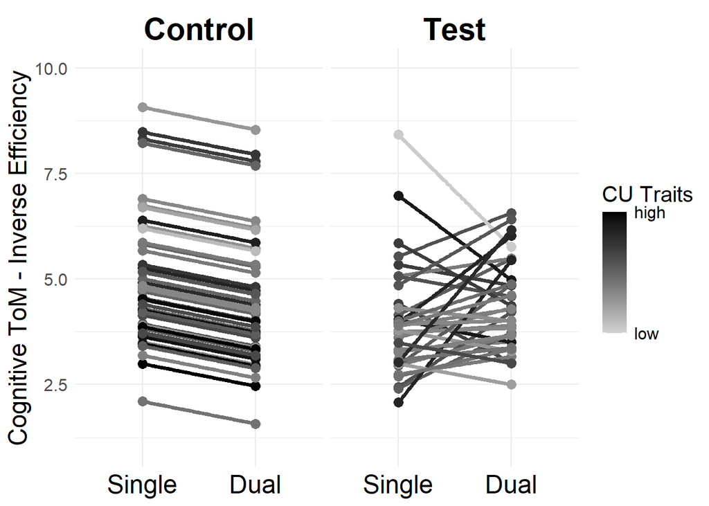

```r
  # CU_______
dat_plot %>%                 # data
  mutate(                    # to properly order control and test groups
    hi_lo = fct_relevel(
      hi_lo2,
      "Control",
      "Test")
    ) %>%
  ggplot(                   # plot
    aes(
      x=factor(time),
      y=random.intercpet.preds_efficiency_ct,
      group = id,
      colour = cu)
    ) +
  geom_smooth(              # fit line
    method='lm',
    formula ='y ~ x',
    size=1.25
    ) +
  geom_point(size=3) +      # plot points
  labs(
    x=NULL,
    y="Cognitive ToM - Inverse Efficiency"
    ) +
  scale_color_continuous(   # scale the color and labels accordingly
    "CU Traits",
    breaks = c(
      min(dat_plot$cu),
      max(dat_plot$cu)
      ),
    labels = c("low", "high"),
    type = "gradient",
    low="light grey",
    high="black"
    ) +
  ylim(1,10) +
  facet_wrap(~hi_lo)  +   # faceting plots by task (single ToM adn dual ToM)
  scale_x_discrete(
    labels=c(
      "Single",
      "Dual"
      )
    ) +
  theme_minimal() +       # setting theme and text parameters
  theme(
    axis.text=element_text(
      size=rel(1.1)
      ),
    axis.title=element_text(
      size=rel(1.6)
      ),
    strip.text.x.top = element_text(
      colour = "black",
      face = "bold",
      size=rel(2.5)
      ),
    axis.text.x = element_text(
      colour = "black",
      face="plain",
      size=rel(1.5)
      ),
    legend.title = element_text(
      size=rel(1.4)
      ),
    legend.text = element_text(
      size=rel(1.1)
      )
    )
```

```r
  # saving plot
ggsave(
  paste0(base_fig,"\\tom_ct_efficiency_individual_line_CU.tiff"),
  plot = last_plot(),
  device = "tiff",
  scale = 1,
  width = 6,
  height = 7,
  units = "in",
  dpi = 300
)
```

##### 3.1.3.4.3 Average line by group

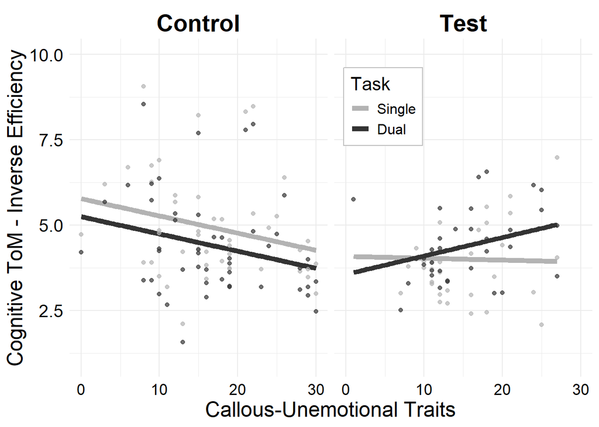

```r
  # CU______________
ggplot(
  data=dat_plot,
  aes(
    x=cu*22,                              # add denominator- rescale mean score
    y=random.intercpet.preds_efficiency_ct,
    group = factor(time_rc),
    colour = factor(time_rc)
    )
  ) +
  geom_smooth(
    method='lm',
    se=FALSE,
    size=2
    ) +
  geom_point(alpha=0.7)+
  labs(
    x="Callous-Unemotional Traits",
    y="Cognitive ToM - Inverse Efficiency"
    ) +
  scale_colour_grey(
    "Task",
    start = .7,
    end= .2
    ) +
  ylim(1,10) +
  facet_grid(. ~ fct_relevel(
    dat_plot$hi_lo2,
    "Control",
    "Test")
    ) +
  theme_minimal() +
  theme(
    axis.text=element_text(
      size=rel(1.1)
    ),
    axis.title=element_text(
      size=rel(1.6)
    ),
    strip.text.x.top = element_text(
      colour = "black",
      face = "bold",
      size=rel(2.25)
    ),
    axis.text.x = element_text(
      colour = "black",
      face="plain",
      size=rel(1.1)
    ),
    axis.text.y = element_text(
      colour = "black",
      face="plain",
      size=rel(1.2)
    ),
    legend.title = element_text(
      size=rel(1.4)
    ),
    legend.text = element_text(
      size=rel(1.1)
    ),
    legend.position = c(0.6,0.8),
    legend.background = element_rect(
      fill="white",
      color = "grey")
    )
```

```r
ggsave(
  paste0(base_fig,"\\tom_ct_efficiency_task_line_CU.tiff"),
  plot = last_plot(),
  device = "tiff",
  scale = 1,
  width = 5.5,
  height = 4.5,
  units = "in",
  dpi = 300
)
```

### 3.1.4 **Physical** ToM *efficiency*

#### 3.1.4.1 Model

```r
pc_inv_eff_p <- lmer(tom_inv_eff_pc  ~
                      cu +
                      sdq_cd +
                      sex_male +
                      race_white +
                      iq +
                      careless +
                      sdq_hyperactivity +
                      sdq_internalizing +
                      time +
                      group_di +
                      order_var +
                      int_gptime +
                      int_cdcu +
                      int_cdcugp +
                      int_cdcugptime +
                      int_cugp +
                      int_cugptime +
                      int_cdgp +
                      int_cdgptime +
                      (1|id),
                    data = dat_long
                    )
```

#### 3.1.4.2 Model performance

```r
(pc_inv_eff_p_st <- performance(pc_inv_eff_p))
```

| AIC | AICc | BIC | R2_conditional | R2_marginal | ICC | RMSE | Sigma |
| --- | --- | --- | --- | --- | --- | --- | --- |
| 861.1758 | 868.0602 | 930.1634 | 0.5145009 | 0.1665389 | 0.4174904 | 2.028424 | 2.535926 |

#### 3.1.4.3 Results (boostrap corrected)

```r
# summary(pc_inv_eff_p)
(tom_pc_df <- mix_boot_report(pc_inv_eff_p))
```

|  | beta.boot | se.boot | t.boot | p.satw_boot | ci.boot_low | ci.boot_hi |
| --- | --- | --- | --- | --- | --- | --- |
| (Intercept) | 9.8577 | 2.1156 | 4.8099 | 8.18e-06 | 5.6742 | 14.07167 |
| cu | 0.4084 | 1.3060 | 0.3227 | 7.48e-01 | -2.1473 | 3.03708 |
| sdq_cd | 2.2449 | 1.2916 | 1.7762 | 8.00e-02 | -0.2526 | 4.81397 |
| sex_male | -0.4396 | 0.7226 | -0.6295 | 5.31e-01 | -1.8854 | 0.94182 |
| race_white | -2.0579 | 0.7390 | -2.8544 | 5.67e-03 | -3.5105 | -0.63299 |
| iq | -0.0316 | 0.0198 | -1.6483 | 1.04e-01 | -0.0689 | 0.00953 |
| careless | -0.0179 | 0.8414 | -0.0203 | 9.84e-01 | -1.6201 | 1.72822 |
| sdq_hyperactivity | -1.7389 | 0.8371 | -2.1354 | 3.62e-02 | -3.3726 | -0.09347 |
| sdq_internalizing | -0.5188 | 1.1950 | -0.4511 | 6.53e-01 | -2.8655 | 1.81746 |
| time | 0.0584 | 0.3903 | 0.1539 | 8.78e-01 | -0.6991 | 0.81727 |

[output cut: 16 more lines]

```r
# saving results to csv
write.csv(
  tom_pc_df,
  tom_change_efficiency_physical,
  row.names=TRUE
  )
```

#### 3.1.4.4 Figures

- not needed because not significant